# Customer Cohort Retention Analysis

Victor Gomes

2026-01-20

# Executive Summary

This analysis tracks customer retention patterns by cohort (first purchase month) to identify when customers churn and how retention varies over time.

**Key Objectives:** - Measure retention rates by cohort and time period - Identify critical drop-off points in customer lifecycle - Compare cohort performance over time - Establish retention benchmarks for the business - Provide actionable recommendations to improve retention

# Introduction to Cohort Analysis

## What is Cohort Analysis?

**Cohort:** A group of customers who made their first purchase in the same month.

**Why Track Cohorts?** - Understand customer lifecycle and churn patterns - Identify when customers typically stop purchasing - Measure effectiveness of retention initiatives - Compare performance of different customer groups - Forecast long-term customer value

## Retention Metrics

**Month 0:** First purchase month (100% retention by definition)  
**Month 1:** % of cohort who purchased in 2nd month  
**Month N:** % of cohort still purchasing N months after first purchase

# Setup

```r
library(tidyverse)
library(lubridate)
library(here)
library(scales)
library(knitr)
library(kableExtra)
library(viridis)
```

# Data Loading

```r
# Load transaction data (customers only)
transactions <- read_csv(here("data", "processed", "retail_customers_only.csv"))

cat("Data loaded:", nrow(transactions), "transactions\n")
```

```
## Data loaded: 401571 transactions
```

```r
cat("Unique customers:", n_distinct(transactions$CustomerID), "\n")
```

```
## Unique customers: 4371
```

```r
cat("Date range:", as.character(min(as.Date(transactions$InvoiceDate))), "to",
    as.character(max(as.Date(transactions$InvoiceDate))), "\n")
```

```
## Date range: 2010-12-01 to 2011-12-09
```

# Cohort Assignment

```r
# Assign each customer to cohort based on first purchase
customer_cohorts <- transactions %>%
  filter(!IsReturn) %>%  # Exclude returns
  group_by(CustomerID) %>%
  summarize(
    FirstPurchase = min(InvoiceDate),
    CohortMonth = floor_date(min(InvoiceDate), "month"),
    .groups = "drop"
  ) %>%
  mutate(Cohort = format(CohortMonth, "%Y-%m"))

# Cohort sizes
cohort_sizes <- customer_cohorts %>%
  count(Cohort, name = "CohortSize")

cohort_sizes %>%
  arrange(Cohort) %>%
  kable(caption = "Customer Acquisition by Cohort Month") %>%
  kable_styling(bootstrap_options = c("striped", "hover"))
```

Customer Acquisition by Cohort Month

| Cohort | CohortSize |
| --- | --- |
| 2010-12 | 885 |
| 2011-01 | 417 |
| 2011-02 | 380 |
| 2011-03 | 452 |
| 2011-04 | 300 |
| 2011-05 | 284 |
| 2011-06 | 242 |
| 2011-07 | 188 |
| 2011-08 | 169 |
| 2011-09 | 299 |
| 2011-10 | 358 |
| 2011-11 | 323 |
| 2011-12 | 41 |

```r
cat("\nTotal cohorts:", n_distinct(customer_cohorts$Cohort), "\n")
```

```
##
## Total cohorts: 13
```

```r
cat("Average cohort size:", round(mean(cohort_sizes$CohortSize)), "\n")
```

```
## Average cohort size: 334
```

# Customer Activity Tracking

```r
# Track all purchase months for each customer
customer_activity <- transactions %>%
  filter(!IsReturn) %>%
  mutate(PurchaseMonth = floor_date(InvoiceDate, "month")) %>%
  distinct(CustomerID, PurchaseMonth) %>%
  inner_join(customer_cohorts, by = "CustomerID") %>%
  mutate(
    MonthsSinceCohort = interval(CohortMonth, PurchaseMonth) %/% months(1)
  ) %>%
  filter(MonthsSinceCohort >= 0)  # Sanity check

cat("Total customer-month combinations:", nrow(customer_activity), "\n")
```

```
## Total customer-month combinations: 13054
```

# Retention Calculation

```r
# Calculate retention rates for each cohort and month
retention_data <- customer_activity %>%
  count(Cohort, MonthsSinceCohort, name = "ActiveCustomers") %>%
  left_join(cohort_sizes, by = "Cohort") %>%
  mutate(RetentionRate = round(ActiveCustomers / CohortSize * 100, 1)) %>%
  arrange(Cohort, MonthsSinceCohort)

# Preview
head(retention_data, 15) %>%
  kable(caption = "Sample Retention Data") %>%
  kable_styling(bootstrap_options = c("striped", "hover"))
```

Sample Retention Data

| Cohort | MonthsSinceCohort | ActiveCustomers | CohortSize | RetentionRate |
| --- | --- | --- | --- | --- |
| 2010-12 | 0 | 885 | 885 | 100.0 |
| 2010-12 | 1 | 324 | 885 | 36.6 |
| 2010-12 | 2 | 286 | 885 | 32.3 |
| 2010-12 | 3 | 340 | 885 | 38.4 |
| 2010-12 | 4 | 321 | 885 | 36.3 |
| 2010-12 | 5 | 352 | 885 | 39.8 |
| 2010-12 | 6 | 321 | 885 | 36.3 |
| 2010-12 | 7 | 309 | 885 | 34.9 |
| 2010-12 | 8 | 313 | 885 | 35.4 |
| 2010-12 | 9 | 350 | 885 | 39.5 |
| 2010-12 | 10 | 331 | 885 | 37.4 |
| 2010-12 | 11 | 445 | 885 | 50.3 |
| 2010-12 | 12 | 235 | 885 | 26.6 |
| 2011-01 | 0 | 417 | 417 | 100.0 |
| 2011-01 | 1 | 92 | 417 | 22.1 |

# Retention Heatmap (The Iconic Visualization)

[figure not shown]

```r
# Create retention matrix for heatmap
retention_matrix <- retention_data %>%
  select(Cohort, MonthsSinceCohort, RetentionRate) %>%
  pivot_wider(names_from = MonthsSinceCohort, values_from = RetentionRate,
              names_prefix = "Month_") %>%
  arrange(Cohort)

# Convert back to long format for ggplot
retention_long <- retention_matrix %>%
  pivot_longer(cols = starts_with("Month_"), names_to = "Month",
               values_to = "Retention") %>%
  mutate(Month = as.numeric(str_remove(Month, "Month_")))

# Create heatmap
ggplot(retention_long, aes(x = Month, y = fct_rev(Cohort), fill = Retention)) +
  geom_tile(color = "white", linewidth = 0.5) +
  geom_text(aes(label = ifelse(!is.na(Retention), paste0(Retention, "%"), "")),
            size = 2.5, color = "white", fontface = "bold") +
  scale_fill_viridis(option = "plasma", na.value = "grey90",
                     limits = c(0, 100), breaks = seq(0, 100, 20)) +
  scale_x_continuous(breaks = seq(0, max(retention_long$Month, na.rm = TRUE), 1)) +
  labs(
    title = "Customer Retention Heatmap by Cohort",
    subtitle = "Percentage of customers still purchasing N months after first purchase",
    x = "Months Since First Purchase",
    y = "Cohort (First Purchase Month)",
    fill = "Retention %",
    caption = "Darker colors = higher retention | Each cell shows % of cohort still active"
  ) +
  theme_minimal(base_size = 11) +
  theme(
    plot.title = element_text(face = "bold", size = 16),
    axis.text.y = element_text(size = 9),
    legend.position = "right",
    panel.grid = element_blank()
  )
```

# Retention Curves

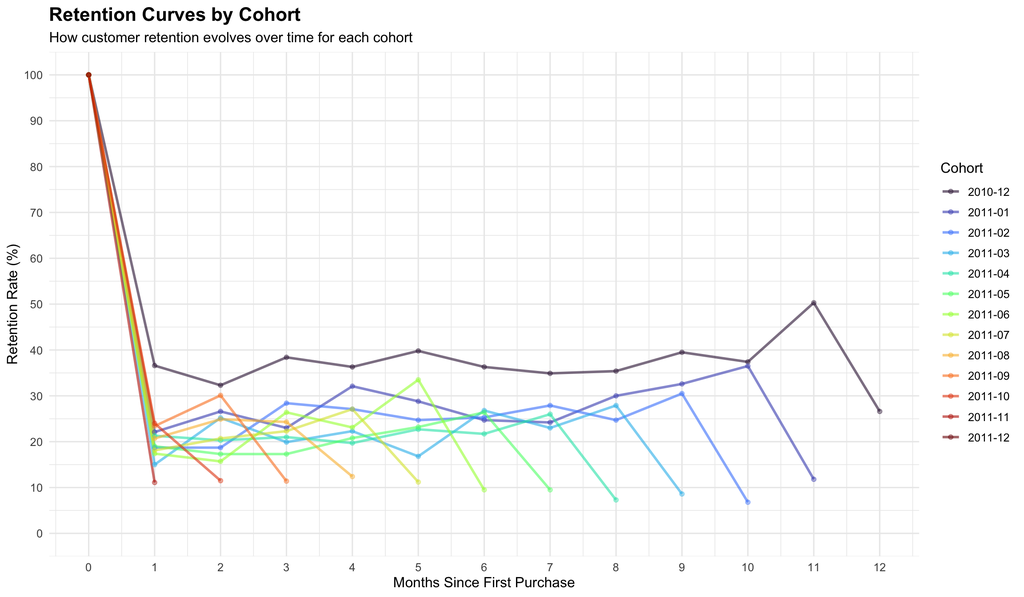

```r
# Plot all cohort retention curves
ggplot(retention_data, aes(x = MonthsSinceCohort, y = RetentionRate,
                           group = Cohort, color = Cohort)) +
  geom_line(alpha = 0.6, linewidth = 1) +
  geom_point(alpha = 0.4, size = 1.5) +
  scale_y_continuous(limits = c(0, 100), breaks = seq(0, 100, 10)) +
  scale_x_continuous(breaks = seq(0, max(retention_data$MonthsSinceCohort), 1)) +
  scale_color_viridis_d(option = "turbo") +
  labs(
    title = "Retention Curves by Cohort",
    subtitle = "How customer retention evolves over time for each cohort",
    x = "Months Since First Purchase",
    y = "Retention Rate (%)",
    color = "Cohort"
  ) +
  theme_minimal(base_size = 12) +
  theme(
    plot.title = element_text(face = "bold", size = 16),
    legend.position = "right"
  )
```

**Insights:**

- **Convergence:** Do all cohorts eventually stabilize at similar retention?
- **Spread:** Wide variation suggests cohort-specific factors
- **Shape:** Steep vs. gradual decline indicates churn patterns

# Average Retention Curve

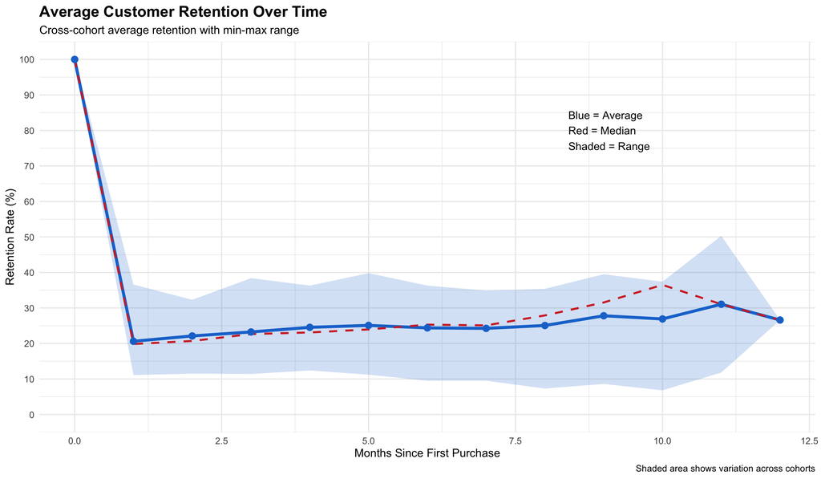

```r
# Calculate average retention by month
avg_retention <- retention_data %>%
  group_by(MonthsSinceCohort) %>%
  summarize(
    AvgRetention = mean(RetentionRate),
    MedianRetention = median(RetentionRate),
    MinRetention = min(RetentionRate),
    MaxRetention = max(RetentionRate),
    .groups = "drop"
  )

# Plot with confidence band
ggplot(avg_retention, aes(x = MonthsSinceCohort)) +
  geom_ribbon(aes(ymin = MinRetention, ymax = MaxRetention),
              fill = "#1976D2", alpha = 0.2) +
  geom_line(aes(y = AvgRetention), color = "#1976D2", linewidth = 1.5) +
  geom_line(aes(y = MedianRetention), color = "#D32F2F",
            linewidth = 1, linetype = "dashed") +
  geom_point(aes(y = AvgRetention), color = "#1976D2", size = 3) +
  scale_y_continuous(limits = c(0, 100), breaks = seq(0, 100, 10)) +
  annotate("text", x = max(avg_retention$MonthsSinceCohort) * 0.7, y = 80,
           label = "Blue = Average\nRed = Median\nShaded = Range",
           hjust = 0, size = 4) +
  labs(
    title = "Average Customer Retention Over Time",
    subtitle = "Cross-cohort average retention with min-max range",
    x = "Months Since First Purchase",
    y = "Retention Rate (%)",
    caption = "Shaded area shows variation across cohorts"
  ) +
  theme_minimal(base_size = 12) +
  theme(plot.title = element_text(face = "bold", size = 16))
```

```r
# Display metrics table
avg_retention %>%
  kable(digits = 1, caption = "Average Retention Metrics by Month",
        col.names = c("Month", "Avg %", "Median %", "Min %", "Max %")) %>%
  kable_styling(bootstrap_options = c("striped", "hover"))
```

Average Retention Metrics by Month

| Month | Avg % | Median % | Min % | Max % |
| --- | --- | --- | --- | --- |
| 0 | 100.0 | 100.0 | 100.0 | 100.0 |
| 1 | 20.6 | 19.9 | 11.1 | 36.6 |
| 2 | 22.1 | 20.7 | 11.5 | 32.3 |
| 3 | 23.2 | 22.6 | 11.4 | 38.4 |
| 4 | 24.5 | 23.1 | 12.4 | 36.3 |
| 5 | 25.1 | 24.0 | 11.2 | 39.8 |
| 6 | 24.4 | 25.3 | 9.5 | 36.3 |
| 7 | 24.2 | 25.1 | 9.5 | 34.9 |
| 8 | 25.1 | 27.9 | 7.3 | 35.4 |
| 9 | 27.8 | 31.6 | 8.6 | 39.5 |
| 10 | 26.9 | 36.5 | 6.8 | 37.4 |
| 11 | 31.0 | 31.0 | 11.8 | 50.3 |
| 12 | 26.6 | 26.6 | 26.6 | 26.6 |

# Cohort Size Context

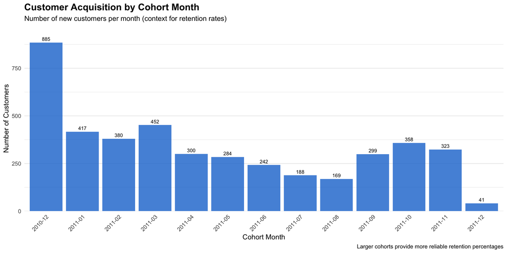

```r
# Visualize cohort sizes over time
ggplot(cohort_sizes, aes(x = Cohort, y = CohortSize)) +
  geom_col(fill = "#1976D2", alpha = 0.8) +
  geom_text(aes(label = CohortSize), vjust = -0.5, size = 3) +
  scale_y_continuous(expand = expansion(mult = c(0, 0.1))) +
  labs(
    title = "Customer Acquisition by Cohort Month",
    subtitle = "Number of new customers per month (context for retention rates)",
    x = "Cohort Month",
    y = "Number of Customers",
    caption = "Larger cohorts provide more reliable retention percentages"
  ) +
  theme_minimal(base_size = 12) +
  theme(
    plot.title = element_text(face = "bold", size = 16),
    axis.text.x = element_text(angle = 45, hjust = 1),
    panel.grid.major.x = element_blank()
  )
```

# Key Retention Metrics

```r
# Calculate critical retention milestones
key_metrics <- avg_retention %>%
  filter(MonthsSinceCohort %in% c(1, 3, 6, 12))

cat("CRITICAL RETENTION BENCHMARKS\n")
```

```
## CRITICAL RETENTION BENCHMARKS
```

```r
cat(rep("=", 60), "\n\n", sep = "")
for(i in 1:nrow(key_metrics)) {
  month <- key_metrics$MonthsSinceCohort[i]
  rate <- key_metrics$AvgRetention[i]
  cat(sprintf("Month %d Retention: %.1f%%\n", month, rate))
}
```

```
## Month 1 Retention: 20.6%
## Month 3 Retention: 23.2%
## Month 6 Retention: 24.4%
## Month 12 Retention: 26.6%
```

```r
# Calculate retention half-life
half_life <- avg_retention %>%
  filter(AvgRetention <= 50) %>%
  slice(1)

if(nrow(half_life) > 0) {
  cat(sprintf("\nRetention Half-Life: Month %d (%.1f%% retention)\n",
              half_life$MonthsSinceCohort, half_life$AvgRetention))
  cat("(Time when 50% of customers have churned)\n")
}
```

```
##
## Retention Half-Life: Month 1 (20.6% retention)
## (Time when 50% of customers have churned)
```

```r
# Calculate plateau retention
plateau <- avg_retention %>%
  filter(MonthsSinceCohort >= 6) %>%
  summarize(PlateauRetention = mean(AvgRetention))

cat(sprintf("\nPlateau Retention (6+ months): %.1f%%\n", plateau$PlateauRetention))
```

```
##
## Plateau Retention (6+ months): 26.6%
```

```r
cat("(Long-term steady-state retention rate)\n\n")
```

```
## (Long-term steady-state retention rate)
```

# Cohort Performance Comparison

```r
# Compare best vs worst cohorts
cohort_performance <- retention_data %>%
  filter(MonthsSinceCohort <= 6) %>%  # Focus on first 6 months
  group_by(Cohort) %>%
  summarize(
    AvgRetention = mean(RetentionRate),
    Month1 = RetentionRate[MonthsSinceCohort == 1][1],
    Month3 = RetentionRate[MonthsSinceCohort == 3][1],
    Month6 = RetentionRate[MonthsSinceCohort == 6][1],
    .groups = "drop"
  ) %>%
  left_join(cohort_sizes, by = "Cohort") %>%
  arrange(desc(AvgRetention))

cat("TOP 5 BEST PERFORMING COHORTS (6-Month Avg):\n\n")
```

```
## TOP 5 BEST PERFORMING COHORTS (6-Month Avg):
```

```r
cohort_performance %>%
  head(5) %>%
  kable(digits = 1, col.names = c("Cohort", "Avg Retention", "M1", "M3", "M6", "Size")) %>%
  kable_styling(bootstrap_options = c("striped", "hover")) %>%
  print()
```

[output not shown]

```r
cat("\n\nBOTTOM 5 COHORTS:\n\n")
```

```
##
##
## BOTTOM 5 COHORTS:
```

```r
cohort_performance %>%
  tail(5) %>%
  kable(digits = 1, col.names = c("Cohort", "Avg Retention", "M1", "M3", "M6", "Size")) %>%
  kable_styling(bootstrap_options = c("striped", "hover")) %>%
  print()
```

[output not shown]

# Critical Drop-Off Analysis

```r
# Calculate month-over-month retention drop
retention_drops <- avg_retention %>%
  arrange(MonthsSinceCohort) %>%
  mutate(
    RetentionDrop = lag(AvgRetention) - AvgRetention,
    DropPct = round((RetentionDrop / lag(AvgRetention)) * 100, 1)
  ) %>%
  filter(!is.na(RetentionDrop))

cat("RETENTION DROP-OFF BY MONTH\n")
```

```
## RETENTION DROP-OFF BY MONTH
```

```r
cat(rep("=", 60), "\n\n", sep = "")
retention_drops %>%
  select(MonthsSinceCohort, AvgRetention, RetentionDrop, DropPct) %>%
  arrange(desc(RetentionDrop)) %>%
  head(5) %>%
  kable(digits = 1,
        col.names = c("Month", "Retention %", "Drop (pp)", "Drop (%)"),
        caption = "Top 5 Months with Steepest Retention Decline") %>%
  kable_styling(bootstrap_options = c("striped", "hover"))
```

Top 5 Months with Steepest Retention Decline

| Month | Retention % | Drop (pp) | Drop (%) |
| --- | --- | --- | --- |
| 1 | 20.6 | 79.4 | 79.4 |
| 12 | 26.6 | 4.4 | 14.3 |
| 10 | 26.9 | 0.9 | 3.2 |
| 6 | 24.4 | 0.7 | 2.8 |
| 7 | 24.2 | 0.1 | 0.6 |

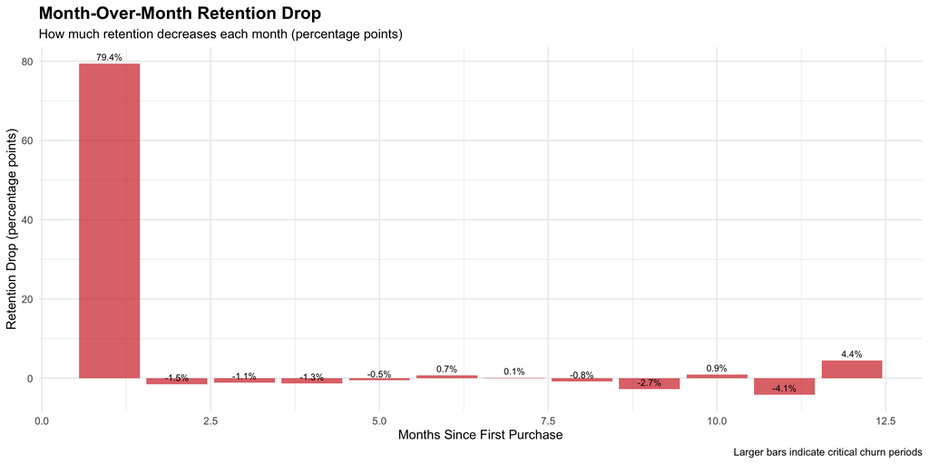

```r
# Visualize retention drops
ggplot(retention_drops, aes(x = MonthsSinceCohort, y = RetentionDrop)) +
  geom_col(fill = "#D32F2F", alpha = 0.7) +
  geom_text(aes(label = sprintf("%.1f%%", RetentionDrop)),
            vjust = -0.5, size = 3) +
  labs(
    title = "Month-Over-Month Retention Drop",
    subtitle = "How much retention decreases each month (percentage points)",
    x = "Months Since First Purchase",
    y = "Retention Drop (percentage points)",
    caption = "Larger bars indicate critical churn periods"
  ) +
  theme_minimal(base_size = 12) +
  theme(plot.title = element_text(face = "bold", size = 16))
```

**Critical intervention windows:** Months with steepest drops are where retention efforts have highest ROI.

# Business Insights & Recommendations

```r
# Calculate key statistics for recommendations
first_month_retention <- avg_retention %>%
  filter(MonthsSinceCohort == 1) %>%
  pull(AvgRetention)

churn_first_month <- 100 - first_month_retention

three_month_retention <- avg_retention %>%
  filter(MonthsSinceCohort == 3) %>%
  pull(AvgRetention)

best_cohort <- cohort_performance %>% slice(1)
worst_cohort <- cohort_performance %>% slice(n())

cat("\n")
```

```r
cat(rep("=", 70), "\n")
cat("                    KEY BUSINESS INSIGHTS\n")
```

```
##                     KEY BUSINESS INSIGHTS
```

```r
cat(rep("=", 70), "\n\n")
cat("1. CRITICAL FIRST MONTH\n")
```

```
## 1. CRITICAL FIRST MONTH
```

```r
cat(sprintf("   • %.1f%% of customers make a second purchase\n", first_month_retention))
```

```
##    • 20.6% of customers make a second purchase
```

```r
cat(sprintf("   • %.1f%% churn after first purchase (MAJOR OPPORTUNITY)\n", churn_first_month))
```

```
##    • 79.4% churn after first purchase (MAJOR OPPORTUNITY)
```

```r
cat("   • Recommendation: Aggressive 2nd purchase incentive program\n\n")
```

```
##    • Recommendation: Aggressive 2nd purchase incentive program
```

```r
cat("2. RETENTION MILESTONES\n")
```

```
## 2. RETENTION MILESTONES
```

```r
cat(sprintf("   • 3-month retention: %.1f%%\n", three_month_retention))
```

```
##    • 3-month retention: 23.2%
```

```r
cat(sprintf("   • 6-month retention: %.1f%%\n",
            avg_retention %>% filter(MonthsSinceCohort == 6) %>% pull(AvgRetention)))
```

```
##    • 6-month retention: 24.4%
```

```r
cat("   • Recommendation: Set quarterly retention targets\n\n")
```

```
##    • Recommendation: Set quarterly retention targets
```

```r
cat("3. COHORT PERFORMANCE VARIATION\n")
```

```
## 3. COHORT PERFORMANCE VARIATION
```

```r
cat(sprintf("   • Best cohort (%s): %.1f%% avg retention\n",
            best_cohort$Cohort, best_cohort$AvgRetention))
```

```
##    • Best cohort (2011-12): 100.0% avg retention
```

```r
cat(sprintf("   • Worst cohort (%s): %.1f%% avg retention\n",
            worst_cohort$Cohort, worst_cohort$AvgRetention))
```

```
##    • Worst cohort (2011-05): 32.0% avg retention
```

```r
cat(sprintf("   • Difference: %.1f percentage points\n",
            best_cohort$AvgRetention - worst_cohort$AvgRetention))
```

```
##    • Difference: 68.0 percentage points
```

```r
cat("   • Recommendation: Analyze best cohort acquisition sources\n\n")
```

```
##    • Recommendation: Analyze best cohort acquisition sources
```

```r
cat("4. CRITICAL INTERVENTION WINDOWS\n")
```

```
## 4. CRITICAL INTERVENTION WINDOWS
```

```r
steepest_drop <- retention_drops %>% arrange(desc(RetentionDrop)) %>% slice(1)
cat(sprintf("   • Steepest drop: Month %d (%.1f pp decline)\n",
            steepest_drop$MonthsSinceCohort, steepest_drop$RetentionDrop))
```

```
##    • Steepest drop: Month 1 (79.4 pp decline)
```

```r
cat("   • Recommendation: Focus retention campaigns on this period\n\n")
```

```
##    • Recommendation: Focus retention campaigns on this period
```

```r
cat("5. LONG-TERM LOYALTY\n")
```

```
## 5. LONG-TERM LOYALTY
```

```r
cat(sprintf("   • Plateau retention: %.1f%%\n", plateau$PlateauRetention))
```

```
##    • Plateau retention: 26.6%
```

```r
cat("   • These are \"lifetime\" customers\n")
```

```
##    • These are "lifetime" customers
```

```r
cat("   • Recommendation: VIP program for customers reaching 6+ months\n\n")
```

```
##    • Recommendation: VIP program for customers reaching 6+ months
```

```r
cat(rep("=", 70), "\n\n")
```

# Strategic Recommendations

```r
cat("ACTIONABLE RETENTION STRATEGIES\n")
```

```
## ACTIONABLE RETENTION STRATEGIES
```

```r
cat(rep("=", 70), "\n\n")
cat("🎯 PRIORITY 1: Improve First-Month Retention\n")
```

```
## 🎯 PRIORITY 1: Improve First-Month Retention
```

```r
cat(sprintf("   Current: %.1f%% | Target: 55-60%%\n", first_month_retention))
```

```
##    Current: 20.6% | Target: 55-60%
```

```r
cat("   Actions:\n")
```

```
##    Actions:
```

```r
cat("   • Welcome email series (Days 0, 3, 7, 14, 30)\n")
```

```
##    • Welcome email series (Days 0, 3, 7, 14, 30)
```

```r
cat("   • 15-20% discount on 2nd purchase within 30 days\n")
```

```
##    • 15-20% discount on 2nd purchase within 30 days
```

```r
cat("   • Product education and usage tips\n")
```

```
##    • Product education and usage tips
```

```r
cat("   • Satisfaction check-in after first purchase\n")
```

```
##    • Satisfaction check-in after first purchase
```

```r
cat(sprintf("   • Expected impact: +10pp retention = £X additional revenue\n\n"))
```

[output not shown]

```r
cat("🎯 PRIORITY 2: Prevent 3-Month Churn\n")
```

```
## 🎯 PRIORITY 2: Prevent 3-Month Churn
```

```r
cat(sprintf("   Current: %.1f%% | Target: 35-40%%\n", three_month_retention))
```

```
##    Current: 23.2% | Target: 35-40%
```

```r
cat("   Actions:\n")
```

```
##    Actions:
```

```r
cat("   • Triggered campaign at 60 days since last purchase\n")
```

```
##    • Triggered campaign at 60 days since last purchase
```

```r
cat("   • Personalized product recommendations\n")
```

```
##    • Personalized product recommendations
```

```r
cat("   • Early warning system for declining activity\n")
```

```
##    • Early warning system for declining activity
```

```r
cat("   • Exclusive offers for at-risk customers\n\n")
```

```
##    • Exclusive offers for at-risk customers
```

```r
cat("🎯 PRIORITY 3: Replicate Best Cohort Success\n")
```

```
## 🎯 PRIORITY 3: Replicate Best Cohort Success
```

```r
cat(sprintf("   Best cohort: %s (%.1f%% retention)\n",
            best_cohort$Cohort, best_cohort$AvgRetention))
```

```
##    Best cohort: 2011-12 (100.0% retention)
```

```r
cat("   Actions:\n")
```

```
##    Actions:
```

```r
cat("   • Analyze acquisition source of best cohort\n")
```

```
##    • Analyze acquisition source of best cohort
```

```r
cat("   • Identify product/campaign mix during that period\n")
```

```
##    • Identify product/campaign mix during that period
```

```r
cat("   • Replicate successful strategies\n")
```

```
##    • Replicate successful strategies
```

```r
cat("   • Test on new cohorts and measure\n\n")
```

```
##    • Test on new cohorts and measure
```

```r
cat("🎯 PRIORITY 4: Build Long-Term Loyalty Program\n")
```

```
## 🎯 PRIORITY 4: Build Long-Term Loyalty Program
```

```r
cat(sprintf("   Target: Increase %.1f%% plateau to 30%%+\n", plateau$PlateauRetention))
```

```
##    Target: Increase 26.6% plateau to 30%+
```

```r
cat("   Actions:\n")
```

```
##    Actions:
```

```r
cat("   • Tiered loyalty program (Bronze/Silver/Gold)\n")
```

```
##    • Tiered loyalty program (Bronze/Silver/Gold)
```

```r
cat("   • Exclusive benefits for 6+ month customers\n")
```

```
##    • Exclusive benefits for 6+ month customers
```

```r
cat("   • Community building (forum, events)\n")
```

```
##    • Community building (forum, events)
```

```r
cat("   • VIP customer service\n\n")
```

```
##    • VIP customer service
```

```r
cat(rep("=", 70), "\n\n")
```

# Summary & Next Steps

```r
cat("COHORT ANALYSIS COMPLETE\n")
```

```
## COHORT ANALYSIS COMPLETE
```

```r
cat(rep("=", 70), "\n\n")
cat("✅ Analyzed", n_distinct(customer_cohorts$Cohort), "customer cohorts\n")
```

```
## ✅ Analyzed 13 customer cohorts
```

```r
cat("✅ Tracked retention across",
    max(retention_data$MonthsSinceCohort), "months\n")
```

```
## ✅ Tracked retention across 12 months
```

```r
cat(sprintf("✅ Identified %.1f%% first-month retention (critical metric)\n",
            first_month_retention))
```

```
## ✅ Identified 20.6% first-month retention (critical metric)
```

```r
cat(sprintf("✅ Established %.1f%% long-term retention benchmark\n",
            plateau$PlateauRetention))
```

```
## ✅ Established 26.6% long-term retention benchmark
```

```r
cat("✅ Pinpointed critical intervention windows\n\n")
```

```
## ✅ Pinpointed critical intervention windows
```

```r
cat("NEXT STEPS:\n")
```

```
## NEXT STEPS:
```

```r
cat("  1. Implement first-purchase follow-up campaign (immediate)\n")
```

```
##   1. Implement first-purchase follow-up campaign (immediate)
```

```r
cat("  2. Set up monthly retention monitoring dashboard\n")
```

```
##   2. Set up monthly retention monitoring dashboard
```

```r
cat("  3. Test retention initiatives on new cohorts\n")
```

```
##   3. Test retention initiatives on new cohorts
```

```r
cat("  4. Deep dive into best vs. worst cohort differences\n")
```

```
##   4. Deep dive into best vs. worst cohort differences
```

```r
cat("  5. Integrate retention metrics into RFM segmentation\n\n")
```

```
##   5. Integrate retention metrics into RFM segmentation
```

**Cohort Analysis Complete!**

*This analysis provides the foundation for data-driven retention strategies and customer lifetime value optimization.*